# Navigation project

[figure not shown]

This jupyter showcases the results of trying out several agents to solve the bananas environment (not provided in this repo).

What has been tried:

- DQN and double DQN agents
- with deep neural network and also duelling network architectures
- with a Memory Buffer

What has not been tried:

- prioritized experience replay. It is a work in progress in the code, the sampling itself is implemented but not the update rules and even the implementation is not good enough (the naïve approach is too slow)
- the pixels environment

Also, this notebook does not show how to train an agent (only at the end), I take advantage of the runs that have been logged using mlflow.

The basis for the implementation has been the DQN code provided in [the course repository](https://github.com/udacity/deep-reinforcement-learning). That implementation with the default parameters already solves the problem.

To run the code below, first we do the necessary inputs and general setup.

*the cells in this notebook are meant to be run in order*

```python
# Imports
from unityagents import UnityEnvironment
from bananas.environment import UnityAdapter
from bananas.problem import load
from bananas.model import QNetwork, DuelingQNetwork
import mlflow
from mlflow.tracking.client import MlflowClient
from mlflow.exceptions import MlflowException

%matplotlib inline
import matplotlib.pyplot as plt
import matplotlib as mpl
import numpy as np
import pandas as pd
from scipy import stats
import colorcet as cc  # for having nice color scales

# Configure matplotlib
%matplotlib inline
plt.style.use("seaborn-whitegrid")

# Configure mlflow and load environment
mlflow.set_tracking_uri('file:./mlruns')    # this is where runs where stored
mlruns_path = "./mlruns"
path_environment = "/Users/claudio/Dropbox/udacity-drl/code/deep-reinforcement-learning/p1_navigation/Banana.app"
banana_environment = UnityAdapter(
    UnityEnvironment(
        file_name=path_environment,
        no_graphics=False,
    ),
    name='bananas')

client = MlflowClient()  # tracking uri has been set above
```

```
INFO:unityagents:
'Academy' started successfully!
Unity Academy name: Academy
        Number of Brains: 1
        Number of External Brains : 1
        Lesson number : 0
        Reset Parameters :

Unity brain name: BananaBrain
        Number of Visual Observations (per agent): 0
        Vector Observation space type: continuous
        Vector Observation space size (per agent): 37
        Number of stacked Vector Observation: 1
        Vector Action space type: discrete
        Vector Action space size (per agent): 4
        Vector Action descriptions: , , ,
```

## Getting the results from the experiments

In every run the following parameters and metrics are logged using mlflow (only the relevant ones represented).

- score
- number of episodes to reach a solution
- number of episodes trained
- type of agent (DQN, DDQN)
- underlying model (deep neural network, duelling neural network)
- learning rate, epsilon, epsilon decay, etc.
- model weights every 100 steps and in the final step (final model)

In mlflow, each execution is called a run and they can be grouped in experiments. And the different runs are grouped by experiments. In this case, I called the experiment *bananas*:

```python
experiment = client.get_experiment_by_name('bananas')
runs = client.search_runs(experiment_ids=experiment.experiment_id)
print(len(runs))
```

```
57
```

Before digging into plots, first the results and main metrics of the experiment are loaded into a DataFrame for easy plotting and exploration

```python
runs[-10].data.tags['mlflow.runName']
```

```
'DQN Agent'
```

```python
# Get everything that is discussed in this notebook in a DataFrame
scores_summary = pd.DataFrame()
for i, run in enumerate(runs):
    score = pd.DataFrame([ dict(m) for m in client.get_metric_history(run_id=run.info.run_id, key='score')])
    avg_100 = score['value'].rolling(100).mean()
    std_100 = score['value'].rolling(100).std()
    k2, p = stats.normaltest(score.value.iloc[-100:])
    row = {
        'run_id': run.info.run_id,
        'episodes_trained': len(score),
        'score_final': avg_100.iloc[-1],
        'score_final_std': std_100.iloc[-1],
        'solved': run.data.params.get('is_solved', 'False') == 'True',
        'normally_distributed': p > 0.05,
        'p_value': p,
        'success_probability': 1 - stats.norm(avg_100.iloc[-1], std_100.iloc[-1]).cdf(13),
        'epsilon_decay': float(run.data.params.get('epsilon_update_function decay decay_factor', 0.995)),
        'artifact': f'{mlruns_path}/{experiment.experiment_id}/{run.info.run_id}/artifacts/model_final.pkl',
        'training':run.data.tags['mlflow.runName'],
        'model': run.data.tags.get('qnetwork', 'QNetwork()').split('(')[0],
    }
    if run.data.params.get('is_solved', 'False') == 'True':
        step_solved = run.data.metrics['episodes_to_solve']
        row['episodes_to_solve'] = step_solved
        score_avg = score.loc[score.step<=step_solved, 'value'].rolling(100).mean().iloc[-1]
        row['score_to_solve'] = score_avg

    scores_summary = scores_summary.append(row, ignore_index=True)
scores_summary.head()
```

|  | artifact | episodes_trained | epsilon_decay | model | normally_distributed | p_value | run_id | score_final | score_final_std | solved | success_probability | training | episodes_to_solve | score_to_solve |
| --- | --- | --- | --- | --- | --- | --- | --- | --- | --- | --- | --- | --- | --- | --- |
| 0 | ./mlruns/0/b074806773e14b0dafdb9b190348007d/ar... | 2000.0 | 0.9995 | DuelingQNetwork | 1.0 | 0.671041 | b074806773e14b0dafdb9b190348007d | 8.20 | 3.120477 | 0.0 | 0.061997 | Double DQN Agent | NaN | NaN |
| 1 | ./mlruns/0/3ff86fdb2b664f81b17780ac122e076b/ar... | 737.0 | 0.9950 | DuelingQNetwork | 1.0 | 0.060784 | 3ff86fdb2b664f81b17780ac122e076b | 15.04 | 3.510216 | 1.0 | 0.719434 | DQN Agent | 533.0 | 13.02 |
| 2 | ./mlruns/0/d54e6cbe594c4f11b4327eff295afdc5/ar... | 2000.0 | 0.9995 | QNetwork | 1.0 | 0.557286 | d54e6cbe594c4f11b4327eff295afdc5 | 8.57 | 3.035996 | 0.0 | 0.072261 | DQN Agent | NaN | NaN |
| 3 | ./mlruns/0/5039679529a1476ca33cd4794b3a170c/ar... | 819.0 | 0.9950 | QNetwork | 1.0 | 0.964486 | 5039679529a1476ca33cd4794b3a170c | 15.39 | 3.504384 | 1.0 | 0.752381 | DQN Agent | 565.0 | 13.06 |
| 4 | ./mlruns/0/5450d1f0fea7423bb85bfb98a6f1da6e/ar... | 2000.0 | 0.9995 | DuelingQNetwork | 1.0 | 0.570691 | 5450d1f0fea7423bb85bfb98a6f1da6e | 7.87 | 3.083534 | 0.0 | 0.048089 | Double DQN Agent | NaN | NaN |

## Let's see all the runs

Before detailing what each run is, first let's plot all the runs (we'll see clusters of experiments)

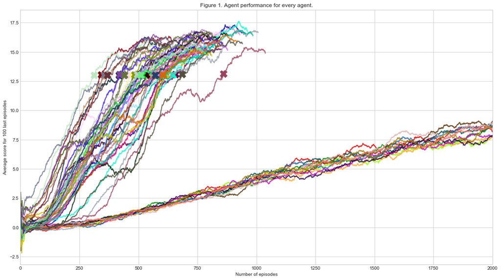

```python
def plot_runs(runs, title='Runs', legend=False):
    plt.figure(figsize=(18,10))
    x_lim = 0
    for i, run in enumerate(runs):
        try:
            score = pd.DataFrame([ dict(m) for m in client.get_metric_history(run_id=run.info.run_id, key='score')])
            color = cc.glasbey_bw[i % len(cc.glasbey_bw)]
            x_lim = max(x_lim, score.step.max())

            row = scores_summary.loc[scores_summary['run_id'] == run.info.run_id, :].iloc[0]
            plt.plot(score.step, score.value.rolling(100, min_periods=1).mean(),
                     linewidth=2, color=color, alpha=0.8, linestyle='-',
                    label=f"{row['training']} {row['model']} decay={row['epsilon_decay']}"
                    )

            if run.data.params.get('is_solved', 'False') == 'True':
                step_solved = run.data.metrics['episodes_to_solve']
                score_avg = score.loc[score.step<=step_solved, 'value'].rolling(100).mean().iloc[-1]
                plt.plot(step_solved, score_avg, marker='X', markersize=15, color=color)
        except MlflowException:
            pass
    plt.xlabel('Number of episodes')
    plt.ylabel('Average score for 100 last episodes')
    plt.title(title)
    plt.xlim([0, x_lim])
    # plt.ylim([0, 18])
    if legend:
        plt.legend()
plot_runs(runs, title = 'Figure 1. Agent performance for every agent.')
```

## A note on stopping criteria

The previous graphic shows:

- the average score for the last 100 episodes for every run (lines)
- an "X" mark when the average score reached 13 or - in other words - when the problem is solved

The "X" is not in the last episode. This is because the stopping criteria was not chosen as just solving the problem because, as it is seen, there is some margin for improvement. In the implementation, this is fully customizable because a function can be passed to the agent to let the agent know then it can stop training. In practice the agent stopped training when:

- the number of episodes reached 2000
- or when it was solved and the average score of the last 200 episodes is greater than the average score of the last 100 episodes

The second criteria looks for score stability in a dynamic way.

For reference, the code to train the agent looks like this:

```
agent = DQN_Agent(
    banana_environment,
    is_finished_function=[loggable(moving_average_cross, 100, 200), loggable(moving_average, 100, 13)],
    is_solved=loggable(moving_average, 100, 13),
    max_train_episodes=2000,
    epsilon_update=loggable(decay, 0.8, min_value=0.01),
    seed=0)
agent.train()
```

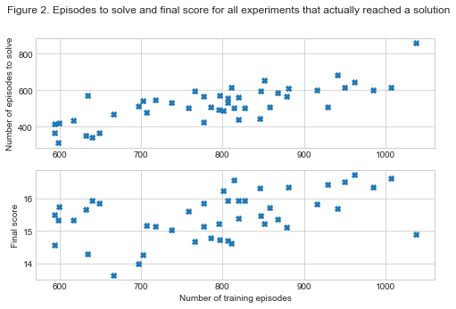

```python
fig, axs = plt.subplots(2, 1, sharex=True, figsize=(8,5))
fig.suptitle('Figure 2. Episodes to solve and final score for all experiments that actually reached a solution')
for ax in axs:
    ax.xaxis.set_tick_params(labelbottom=True)
condition = scores_summary['score_final'] > 13
axs[0].plot(
    scores_summary.loc[condition, 'episodes_trained'],
    scores_summary.loc[condition, 'episodes_to_solve'],
    'X'
)
axs[1].plot(
    scores_summary.loc[condition, 'episodes_trained'],
    scores_summary.loc[condition, 'score_final'],
    'X'
)

axs[0].set(ylabel='Number of episodes to solve')
axs[1].set(ylabel='Final score', xlabel='Number of training episodes');
```

Figure 2 shows that the scores reached values significantly above 13. None of the agents actually needed more than 1000 episodes to reach the value of 13, although it is true that two succesful experiments continued training for more than 1000 episodes.

## On failed experiments

In the implementation, the way of making ε is configurable when defining the agent. It was always chosen like with this function:

```
def decay(agent, decay_factor, min_value=0):
    agent.epsilon = max(agent.epsilon * decay_factor, min_value)
    return agent.epsilon
```

The following cross table shows whether the experiment was solved or not based only on the decay factor. 0.995 is the default value, that is why there are more experiments with that value.

```python
scores_summary.groupby(['epsilon_decay', 'solved', ]).count()
pd.crosstab(scores_summary['solved'], scores_summary['epsilon_decay'])
```

| epsilon_decay solved | 0.1000 | 0.4000 | 0.8000 | 0.9950 | 0.9995 |
| --- | --- | --- | --- | --- | --- |
| 0.0 | 0 | 0 | 0 | 0 | 12 |
| 1.0 | 10 | 5 | 7 | 23 | 0 |

It looks like increasing the decay factor does not help. It is because in episode 2000 the agent where still exploring (see future work at the end for a comment on this):

```python
0.9995 ** 2000
```

```
0.367787452146011
```

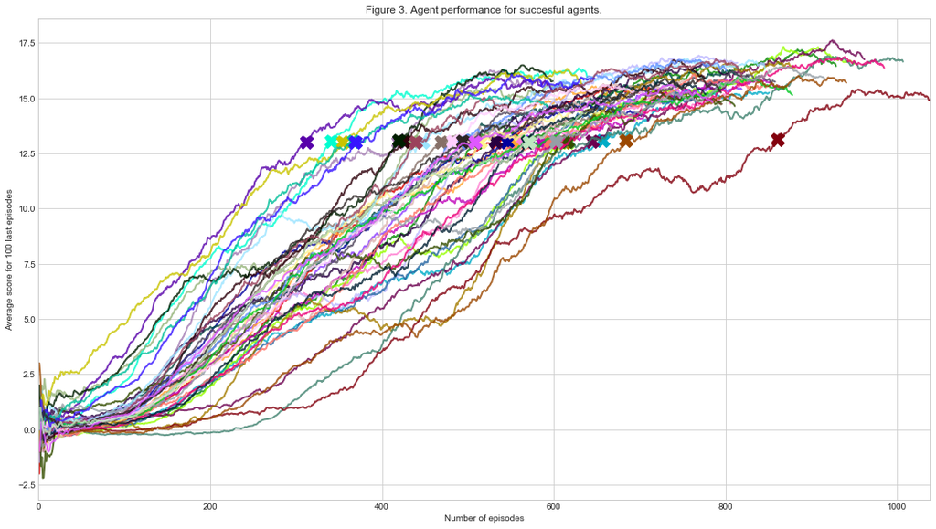

```python
valid_runs = [
    run for run in runs
    if float(run.data.params.get('epsilon_update_function decay decay_factor', 0.995)) < 0.9995
]
plot_runs(valid_runs, title = 'Figure 3. Agent performance for succesful agents.')
```

## A closer look at the agents

All of the agents above reached a good solution within a reasonable number of episodes. It is difficult to say which one is the best. We want the agents to have a good score because they are good, not because they are lucky or have a good run. That is why the *success probability* has been computed.

The success probability is the probability of an agent getting a score greater or equal than 13. This is calculated assumming that the score distribution of the last 100 runs is a normal distribution, which is not always true. The reason for this not being always true that I can think of:

- extremely bad luck (highly unlikely)
- the agent is not yet stabilized (its model weights)

Maybe another stop criteria could have been used.

Let's first show a summary table.

```python
scores_summary.loc[scores_summary['solved'] == True, :].groupby(['training', 'model']).agg(
    {"score_final": [len, np.max, np.min],
     "normally_distributed": [np.sum],
     "success_probability": [np.max, np.min],
    "episodes_to_solve": [np.min]})
```

| training | model | score_final len | score_final amax | score_final amin | normally_distributed sum | success_probability amax | success_probability amin | episodes_to_solve amin |
| --- | --- | --- | --- | --- | --- | --- | --- | --- |
| DQN Agent | DuelingQNetwork | 9.0 | 16.74 | 13.98 | 6.0 | 0.847760 | 0.596180 | 341.0 |
|  | QNetwork | 16.0 | 15.94 | 14.29 | 10.0 | 0.795092 | 0.633913 | 312.0 |
| Double DQN Agent | DuelingQNetwork | 9.0 | 16.64 | 14.89 | 7.0 | 0.860308 | 0.711576 | 418.0 |
|  | QNetwork | 11.0 | 16.54 | 13.64 | 4.0 | 0.837675 | 0.576997 | 368.0 |

Now let's get for every combination of the above agents get the four agents (maybe they are all the same):

- The one with the highest *final score*
- The one with the highest probability of succeeding, as defined above
- The one that took the shortest number of episodes to reach an average score of 13
- The one that trained for the least amount of episodes

|  | 0 | 1 | 2 | 3 | 4 | 5 | 6 | 7 | 8 |
| --- | --- | --- | --- | --- | --- | --- | --- | --- | --- |
| training | DQN Agent | DQN Agent | Double DQN Agent | Double DQN Agent | DQN Agent | DQN Agent | Double DQN Agent | Double DQN Agent | DQN Agent |
| model | DuelingQNetwork | QNetwork | DuelingQNetwork | QNetwork | DuelingQNetwork | QNetwork | DuelingQNetwork | QNetwork | QNetwork |
| episodes_trained | 962 | 806 | 1007 | 950 | 639 | 598 | 593 | 648 | 593 |
| epsilon_decay | 0.995 | 0.1 | 0.4 | 0.995 | 0.1 | 0.8 | 0.1 | 0.8 | 0.8 |
| normally_distributed | 1 | 1 | 1 | 0 | 0 | 1 | 0 | 0 | 0 |
| p_value | 0.212588 | 0.482111 | 0.577196 | 0.000591635 | 0.00511828 | 0.264822 | 0.0213087 | 0.000331546 | 0.036496 |
| score_final | 16.74 | 15.94 | 16.64 | 16.54 | 15.94 | 15.35 | 15.52 | 15.86 | 14.58 |
| score_final_std | 3.64212 | 3.56702 | 3.36506 | 3.5941 | 4.03975 | 4.56905 | 4.32162 | 4.31352 | 3.70143 |
| solved | 1 | 1 | 1 | 1 | 1 | 1 | 1 | 1 | 1 |
| success_probability | 0.84776 | 0.795092 | 0.860308 | 0.837675 | 0.766622 | 0.696489 | 0.720092 | 0.746345 | 0.66526 |
| episodes_to_solve | 644 | 532 | 617 | 617 | 341 | 312 | 418 | 368 | 366 |
| score_to_solve | 13.05 | 13.07 | 13.06 | 13.01 | 13.04 | 13.02 | 13.03 | 13.03 | 13.04 |

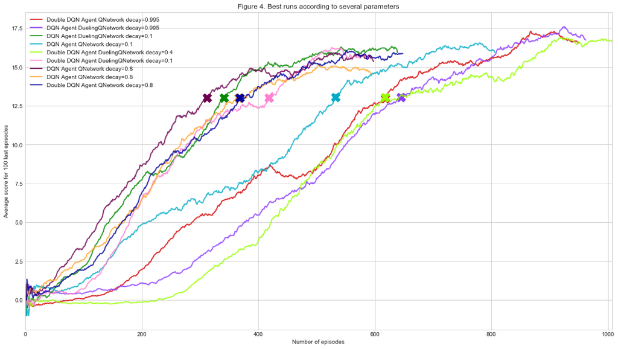

```python
df = scores_summary.loc[scores_summary['solved'] == True, :]
var_ascending = [
    ('score_final', False),
    ('success_probability', False),
    ('episodes_to_solve', True),
    ('episodes_trained', True)
]
picked = pd.DataFrame()
for var, ascending in var_ascending:
    picked = picked.append(
        df.sort_values(var, ascending=ascending).groupby(['training', 'model']).first())
picked = picked.drop_duplicates().reset_index()
picked_ids = list(picked['run_id'])
plot_runs([
    run for run in runs if run.info.run_id in picked_ids
], title='Figure 4. Best runs according to several parameters', legend=True)
picked.drop(['artifact', 'run_id'], axis=1).transpose()
```

## Which agent is the best?

To me, this one:

DQN agent with a duelling network architecture using an epsilon decay factor of 0.1.

I chose it because:

- It got trained fast (341 episodes to solution, 639 in total)
- Has a very high final score, 15.94. Not the highest though

It is also tempting to choose this one: Double DQN agent with a duelling network architecture using an epsilon decay factor of 0.4.

Because it has the highest chance of succeding and a very high score (16.64), but it did take a while to stabilize.

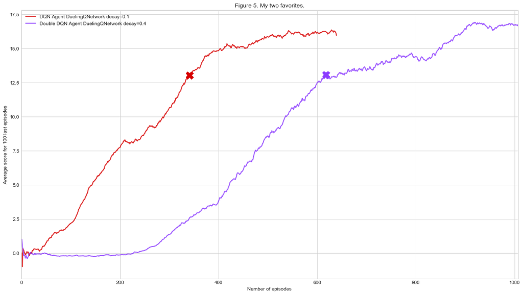

```python
best_agents = picked.iloc[[2,4],:]
picked_ids = list(best_agents['run_id'])
plot_runs([
    run for run in runs if run.info.run_id in picked_ids
], title='Figure 5. My two favorites.', legend=True)
```

## But I just want to see an agent pick bananas!

After all this analysis, the code has a feature. An agent can be loaded and you can see it in action!

```python
agent_path = best_agents.iloc[0,:]['artifact']
print(agent_path)
# Choose an agent and make it play
agent = load(agent_path, banana_environment)
agent.see_episode()
```

```
2020-03-26 00:13:32,175|INFO|bananas|Loading model from ./mlruns/0/76ccb205a98540d8ab83509fb05e5846/artifacts/model_final.pkl
INFO:bananas:Loading model from ./mlruns/0/76ccb205a98540d8ab83509fb05e5846/artifacts/model_final.pkl
2020-03-26 00:13:32,184|DEBUG|bananas|agent class: <class 'bananas.agents.double_dqn_agent.Double_DQN_Agent'>
DEBUG:bananas:agent class: <class 'bananas.agents.double_dqn_agent.Double_DQN_Agent'>
2020-03-26 00:13:32,186|DEBUG|bananas|model class: <class 'bananas.model.DuelingQNetwork'>
DEBUG:bananas:model class: <class 'bananas.model.DuelingQNetwork'>
```

```
./mlruns/0/76ccb205a98540d8ab83509fb05e5846/artifacts/model_final.pkl
```

```python
# In the rubric it says that a trained agent must be in the root directory
# here it is
agent = load('trained_agent.pkl', banana_environment)
agent.see_episode()
```

```
2020-03-26 00:14:03,612|INFO|bananas|Loading model from trained_agent.pkl
INFO:bananas:Loading model from trained_agent.pkl
2020-03-26 00:14:03,624|DEBUG|bananas|agent class: <class 'bananas.agents.double_dqn_agent.Double_DQN_Agent'>
DEBUG:bananas:agent class: <class 'bananas.agents.double_dqn_agent.Double_DQN_Agent'>
2020-03-26 00:14:03,633|DEBUG|bananas|model class: <class 'bananas.model.DuelingQNetwork'>
DEBUG:bananas:model class: <class 'bananas.model.DuelingQNetwork'>
```

## Future work

### Some basics

- Fix bugs
- Implement prioritized replay
- Try with the pixels environment. This requires a different network acrhitecture.
- Study the effect of all the parameters that have been tried, for example the effect of increasing the *t_every* parameter. Several values were tried, but the results have not been fully analyzed. The same is valid for the *decay factor*.

### Other ideas

- The way of decaying ε as exploration-exploitation dicotomy can be done diferently. Using always zero (always exploit) does not stop the agent from learning. However it does look like exploring makes sense at the beginning and not at the end. Maybe an step function is better than exponential decay.
- Explore other neural network configurations. It looks like for this environment smaller networks could work too.
- Out of curiosity, get the agents that did not succeed in training and make them play with ε=0. My suspition is that they did learn to play, however because they were most of the time choosing actions at random they did not show it.